# APLICAÇÃO DE MODELO MISTO DE REGRESSÃO SEGMENTADA

Henrique Aparecido Laureano [[Lattes](http://lattes.cnpq.br/2224901552085090), [GitLab](https://gitlab.c3sl.ufpr.br/u/hal11), [LEG GitLab](http://git.leg.ufpr.br/u/laureano)]

Novembro de 2015

# QUAIS PACKAGES SÃO UTILIZADOS?

> - `graphics`
> - `latticeExtra`
>   - Gráficos
> - `lme4`
>   - Modelos
> - `wzRfun`
>   - Representação gráfica das bandas de confiança
> - `htmlTable`
>   - Tabelas

# QUAL É A IDEIA DO DATASET?

> *Indivíduos infectados pelo HIV em terapia anti-retroviral*
> - **100 indivíduos acompanhados** durante um ano (12 meses)
>   - **Para cada indivíduo** foram feitas **sete avaliações** (mês 0, 1, 2, 4, 6, 8 e 12)
> - **Em cada avaliação** foi **mensurado a quantidade de CD4 no sangue** que reflete o estado do sistema imunológico do indivíduo
>   - Maior contagem de CD4, melhor sistema imunológico. Contagens abaixo de 1000 células/mm$^{3}$ sugerem que o sistema está um pouco comprometido
> - **50 indívuos** alocados **no grupo 1** e **50 indivíduos** alocados **no grupo 2**
>   - **Grupo 1:** **Indivíduos tratados** com terapia anti-retroviral **durante 4 meses**
>   - **Grupo 2:** **Indivíduos tratados** com terapia anti-retroviral **durante todo o período de acompanhamento**

- Indivíduo (`Id`): Fator com 100 níveis
- `Meses`: Vetor de números inteiros com sete valores únicos. 0, 1, 2, 4, 6, 8 e 12
- `CD4`: Vetor de números inteiros com as contagens de CD4
- `Grupo`: Fator com 2 níveis, 1 e 2

## QUAIS OS OBJETIVOS NO ESCOPO DE INFERÊNCIA?

> - Existe diferença entre os `Grupos` em relação as contagens de `CD4`?
> - E os `Meses`? Como as contagens de `CD4` se comportam com o passar dos `Meses`?

# ANÁLISE DESCRITIVA

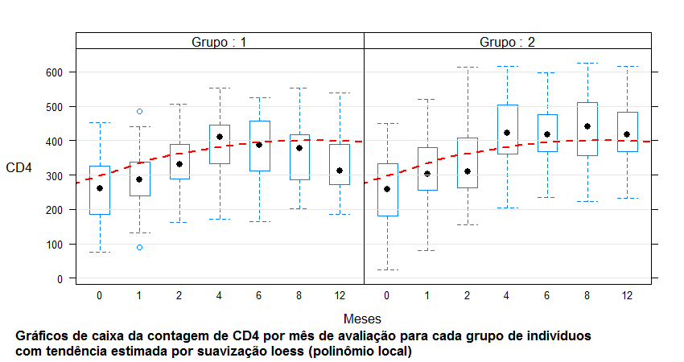

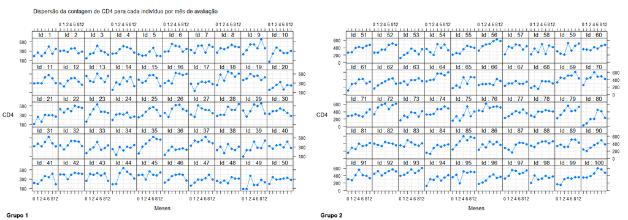

# AJUSTANDO MODELOS

> Estamos lidando com contagens de `CD4`, logo, dada a palavra ‘contagens’ inicialmente se pensa numa distribuição Poisson. Contudo, ela também pode ser pensada como uma taxa, já que é dada por células/mm$^{3}$

> Num primeiro momento iremos assumir uma distribuição Normal

> Como vamos utilizar um modelo segmentado criamos uma nova variável chamada `tMeses` (t de truncada)

> Escolhemos utilizar um ponto de quebra igual a 4, já que sabemos que a distinção entre os grupos ocorre no mês 4

```r
data$tMeses <- with(data, ifelse(Meses < 4, 0, Meses - 4))
```

## INTERCEPTO ALEATÓRIO

### MODELO 1

O primeiro modelo proposto pode ser escrito da seguinte maneira

> ${\rm CD4}_{ij} = \mu + \beta_{m} {\rm Meses}_{i} + \beta_{t} {\rm tMeses}_{i} + \beta_{g} {\rm Grupo}_{j} + \beta_{tg} {\rm tMeses}_{i} \cdot {\rm Grupo}_{j} + \gamma_{j}^{0} + \epsilon_{ij}$

onde $i$ indexa o mês e $j$ indexa o indivíduo

Nesse modelo temos o efeito fixo de `Meses`, `Grupo`, e sua interação, e como efeito aleatório temos os indivíduos (`Id`)

```r
# lm.id: modelo linear com efeito aleatório de indivíduo (intercepto aleatório)
lm.id <- lmer(CD4 ~ Meses + tMeses*Grupo + (1|Id), data)
```

#### E A QUALIDADE DO AJUSTE? FICOU BOM?

*Verificação dos pressupostos e ajuste do modelo*  
**O ajuste do modelo se mostra satisfatório e os pressupostos são atendidos**

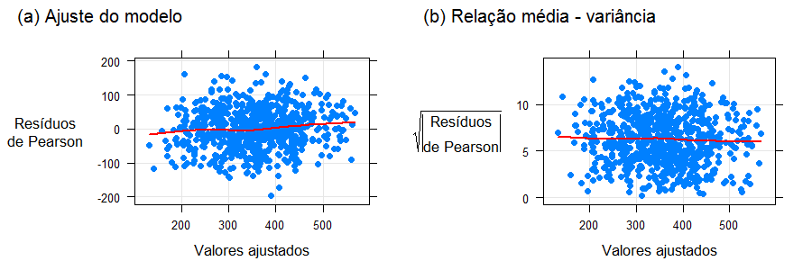

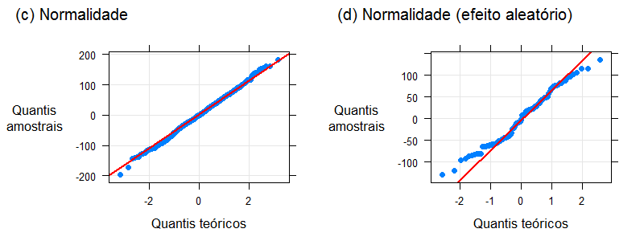

#### INFERÊNCIA

> *Construção da banda de confiança*

```r
pred <- expand.grid(Meses = seq(0, 12, .2)
                    , Grupo = levels(data$Grupo)
                    , CD4 = 0)
pred$tMeses <- with(pred, ifelse(Meses <= 4, 0, Meses - 4))
X <- model.matrix(terms(lm.id), pred)
pred$CD4 <- X %*% fixef(lm.id)
var <- diag(X %*% tcrossprod(vcov(lm.id), X))
tlval <- qt(p = .025
            , df = df.residual(lm.id)) * sqrt(var)
tuval <- qt(p = .975
            , df = df.residual(lm.id)) * sqrt(var)
pred$lwr <- pred$CD4 + tlval
pred$upr <- pred$CD4 + tuval
```

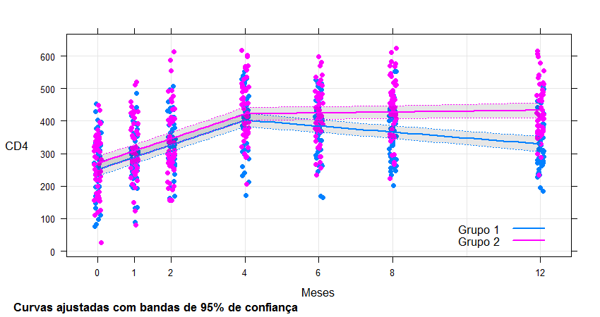

Nesse modelo temos o efeito principal de `tMeses` e `Grupo`, além de sua interação

A presença do efeito principal de `Grupo` faz com que tenhamos duas retas distintas, uma para cada `Grupo`

No gráfico acima observamos que a curva ajustada para os indivíduos do `Grupo` 2 se mostra mais elevada, i.e., indica maiores contagens de `CD4`. Esse comportamento já era de certa forma esperado, já que com a dispersão dos pontos dada no fundo do gráfico podemos observar em geral maiores contagens de `CD4` nos indivíduos do `Grupo` 2

> *Lembrando. `Grupo` **1**: Indivíduos tratados com **terapia** anti-retroviral **durante 4 meses**. `Grupo` **2**: Indivíduos tratados com **terapia** anti-retroviral **durante todo o período** de acompanhamento*

Do ponto de quebra em diante para os indivíduos do `Grupo` 1 observamos uma queda nas contagens de `CD4`. Já nos indivíduos do `Grupo` 2 observamos uma estagnação

Existe a hipótese de que após um determinado tempo a parada no tratamento (`Grupo` 1) é benéfica, o que é refletido em maiores contagens de `CD4`. Pelo gráfico vemos que essa hipótese a princípio não é confirmada

Nos `Meses` em que todos os indivíduos estão sob tratamento as bandas de confiança dos grupos chegam a se sobrepor, a partir do ponto de quebra, i.e., quando o `Grupo` 1 para de receber o tratamento, isso já não ocorre mais

**Estimativas do modelo em células/mm$^{3}$**

Estimativa

Erro padrão

Mês 0 - `Grupo` 1

251.1166

10.6206

Mês 0 - `Grupo` 2

270.1609

10.6206

Inclinação - Mês ≤ 4

37.923

1.8412

Inclinação - `Grupo` 1

-9.1967

1.3266

Inclinação - `Grupo` 2

1.3669

1.3266

σ<sub>Id</sub>

63.7719

σ

62.8239

> Considerar um efeito aleatório dos indivíduos significa inserir um diferente intercepto para cada indivíduo. As inclinações das retas são as mesmas, o que muda é apenas o intercepto

O desvio padrão para o intercepto é de 63.77 células/mm$^{3}$

Existe certa variação adicional nas contagens de `CD4` com desvio padrão de 62.82. Sua alta estimativa pode indica uma considerável variação mês a mês nas contagens de `CD4` dos indivíduos

### MODELO 2

> ${\rm CD4}_{ij} = \mu + \beta_{m} {\rm Meses}_{i} + \beta_{tg} {\rm tMeses}_{i} \cdot {\rm Grupo}_{j} + \gamma_{j}^{0} + \epsilon_{ij}$

onde $i$ indexa o mês e $j$ indexa o indivíduo

Nesse modelo temos o efeito fixo de `Meses`, sua interação com `Grupo`, e como efeito aleatório temos os indivíduos (`Id`)

```r
# lm2.id: modelo linear com efeito aleatório de indivíduo (intercepto aleatório)
lm2.id <- lmer(CD4 ~ Meses + tMeses:Grupo + (1|Id), data)
```

#### E A QUALIDADE DO AJUSTE? FICOU BOM?

*Verificação dos pressupostos e ajuste do modelo*  
**O ajuste do modelo se mostra satisfatório e os pressupostos são atendidos**

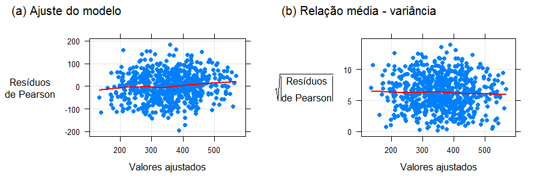

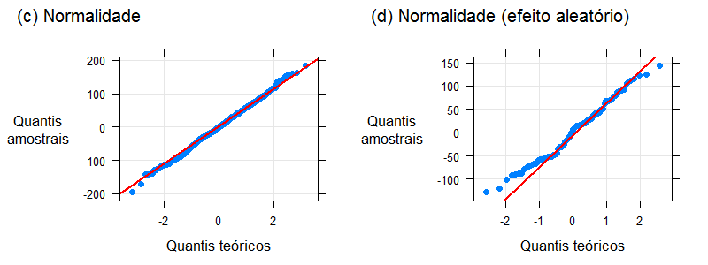

#### INFERÊNCIA

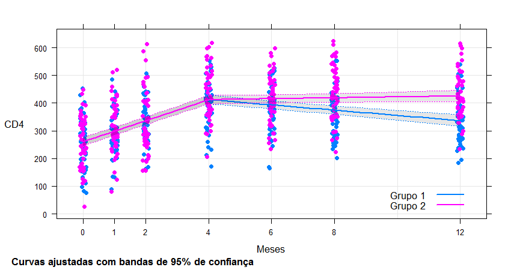

Diferente do *modelo 1*, aqui não temos o efeito principal de `tMeses` e `Grupo`, apenas o efeito de sua interação

A ausência do efeito principal de `Grupo` faz com que tenhamos uma única reta até o ponto de quebra, o que de certa forma faz sentido, já que até o mês 4 todos estão sendo tratados

As bandas de confiança não se tocam do mês 6 (aproximadamente) em diante, o que indica uma diferença significativa entre as contagens de `CD4` dos dois grupos

> *Lembrando novamente. `Grupo` **1**: Indivíduos tratados com **terapia** anti-retroviral **durante 4 meses**. `Grupo` **2**: Indivíduos tratados com **terapia** anti-retroviral **durante todo o período** de acompanhamento*

**Estimativas do modelo em células/mm$^{3}$**

Estimativa

Erro padrão

Mês 0

260.6388

8.0029

Inclinação - Mês ≤ 4

37.923

1.8412

Inclinação - `Grupo` 1

-9.4679

1.3114

Inclinação - `Grupo` 2

1.6381

1.3114

σ<sub>Id</sub>

64.0638

σ

62.8263

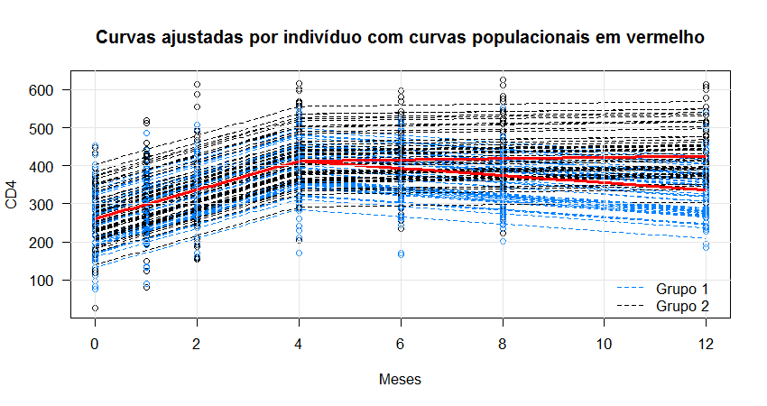

### COM QUAL MODELO FICAMOS?

**Comparando as estimativas de contagens de `CD4` dos dois modelos**

|  | Modelo 1 Mínimo | Modelo 1 Estimativa | Modelo 1 Máximo |  | Modelo 2 Mínimo | Modelo 2 Estimativa | Modelo 2 Máximo |
| --- | --- | --- | --- | --- | --- | --- | --- |
| Mês 0 - `Grupo` 1 | 230.346 | 251.1166 | 271.8873 |  | 244.9419 | 260.6388 | 276.3356 |
| Mês 0 - `Grupo` 2 | 221.9455 | 270.1609 | 318.3763 |  | 244.9419 | 260.6388 | 276.3356 |
| Inclinação - Mês ≤ 4 | 34.3176 | 37.923 | 41.5284 |  | 34.3173 | 37.923 | 41.5287 |
| Inclinação - `Grupo` 1 | -18.1033 | -9.1967 | -0.2901 |  | -18.3642 | -9.4679 | -0.5777 |
| Inclinação - `Grupo` 2 | -10.8276 | 1.3669 | 13.5614 |  | -7.2521 | 1.6381 | 10.5344 |
| σ<sub>Id</sub> | 54.0232 | 63.7719 | 74.2194 |  | 54.5817 | 64.0638 | 74.9518 |
| σ | 59.2815 | 62.8239 | 66.3866 |  | 59.2862 | 62.8263 | 66.3931 |

*As estimativas dos parâmetros não é um critério válido para decidir com qual modelo ficamos, mas de qualquer forma é interessante compará-las*

> Nas análises gráficas de resíduos verificamos que ambos os modelos ajustaram satisfatóriamente

**Medidas de comparação dos modelos**

| Modelo 1 AIC | Modelo 1 BIC | Modelo 1 logLik | Modelo 1 REML |  | Modelo 2 AIC | Modelo 2 BIC | Modelo 2 logLik | Modelo 2 REML |
| --- | --- | --- | --- | --- | --- | --- | --- | --- |
| 7982.3992 | 8014.2568 | -3984.1996 | 7968.3992 |  | 7989.3603 | 8016.6668 | -3988.6801 | 7977.3603 |

O AIC, BIC e REML são critérios do tipo menor é melhor, já a log verossimilhança é do tipo maior é melhor

> Todos os critérios nos levam a escolher o modelo 1, i.e., o modelo com os efeitos principais de `tMeses` e `Grupo`, ou seja, considerando uma curva para os indivíduos de cada `Grupo`

```r
anova(lm.id, lm2.id)
```

```
Data: data
Models:
lm2.id: CD4 ~ Meses + tMeses:Grupo + (1 | Id)
lm.id: CD4 ~ Meses + tMeses * Grupo + (1 | Id)
       Df    AIC    BIC  logLik deviance  Chisq Chi Df Pr(>Chisq)
lm2.id  6 8002.4 8029.7 -3995.2   7990.4
lm.id   7 8002.5 8034.4 -3994.3   7988.5 1.8661      1     0.1719
```

## INTERCEPTO E INCLINAÇÃO INICIAL ALEATÓRIA

### MODELO 3

> $\begin{align} {\rm CD4}_{ij} & = \mu + \beta_{m} {\rm Meses}_{i} + \beta_{t} {\rm tMeses}_{i} + \beta_{g} {\rm Grupo}_{j} + \beta_{tg} {\rm tMeses}_{i} \cdot {\rm Grupo}_{j} \\ & + \gamma_{j}^{0} + \gamma_{j}^{1} {\rm Meses}_{i} + \epsilon_{ij} \end{align}$

onde $i$ indexa o mês e $j$ indexa o indivíduo

O que diferencia esse modelo do modelo 1 é o acréscimo de mais um termo de efeito aleatório

```r
# lm.idm: modelo linear com efeito aleatório de indivíduo (intercepto aleatório)
#         e de indivíduo dentro de meses (inclinação aleatória até o ponto de quebra)
lm.idm <- lmer(CD4 ~ Meses + tMeses*Grupo + (Meses|Id), data)
```

#### E A QUALIDADE DO AJUSTE? FICOU BOM?

*Verificação dos pressupostos e ajuste do modelo*  
**O ajuste do modelo se mostra satisfatório e os pressupostos são atendidos**

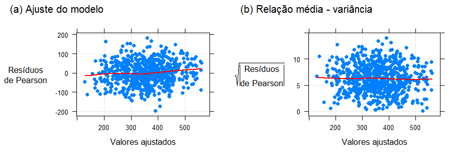

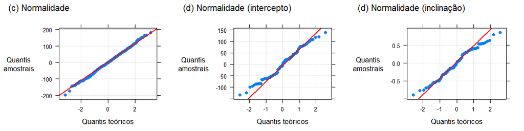

#### INFERÊNCIA

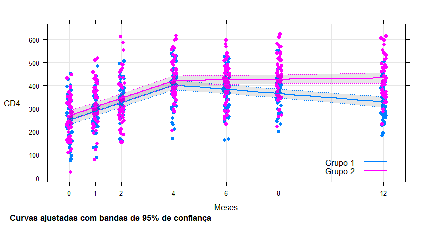

**Estimativas de efeito fixo do modelo**

|  | Estimativa | Erro padrão |
| --- | --- | --- |
| Mês 0 - `Grupo` 1 | 250.9049 | 10.8059 |
| Mês 0 - `Grupo` 2 | 270.3726 | 10.8059 |
| Inclinação - Mês ≤ 4 | 37.923 | 1.8409 |
| Inclinação - `Grupo` 1 | -9.1949 | 1.3279 |
| Inclinação - `Grupo` 2 | 1.3651 | 1.3279 |

> Considerar um efeito aleatório dos indivíduos e dos indivíduos dentro dos meses significa inserir um diferente intercepto e inclinação até o ponto de quebra para cada indivíduo

```r
VarCorr(lm.idm)
```

```
 Groups   Name        Std.Dev. Corr
 Id       (Intercept) 65.76355
          Meses        0.42164 -1.000
 Residual             62.79822
```

O desvio padrão para o intercepto é de 65.76 células/mm$^{3}$

O desvio padrão para a inclinação é de 0.42

Existe certa variação adicional nas contagens de `CD4` com desvio padrão de 62.8

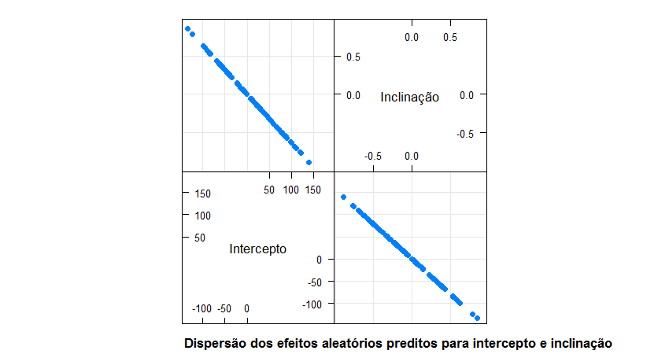

> Atente para o valor da correlação estimada entre o intercepto e a inclinação aleatória. A estimativa é de -1!

> Essa correlação perfeia pode ser observada no gráfico acima

> Isso mostra que o intercepto e a inclinação são altamente correlacionados e que essa correlação é negativa, i.e., para baixos valores de um deles temos altos valores do outro

> Observe no gráfico abaixo que as inclinações diferem pouco de um indivíduo para outro e que a baixa estimativa do desvio padrão, 0.42, indica que pouca variabilidade dos dados é captada por este componente

> Com base em todos os gráficos até aqui apresentados podemos afirmar que para baixos valores de intercepto temos altos valores de inclinações

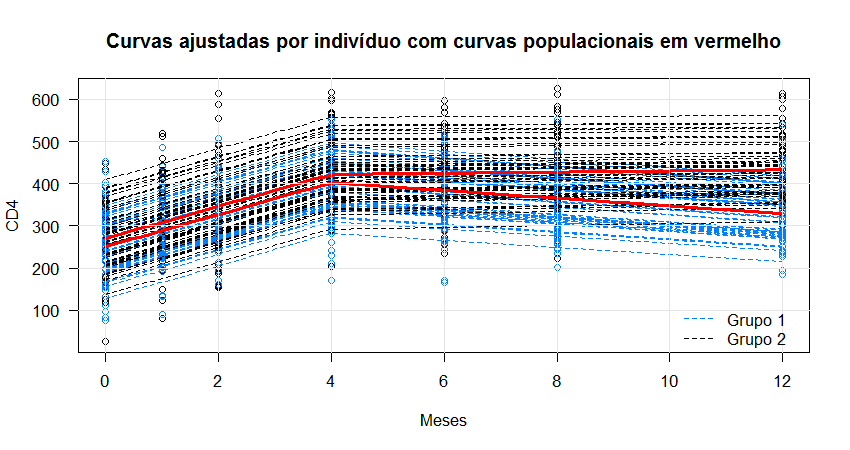

> Dada essa altíssima correlação e a baixa estimativa, há indícios de que o efeito aleatório na inclinação é desnecessário

```r
anova(lm.id, lm.idm)
```

```
Data: data
Models:
lm.id: CD4 ~ Meses + tMeses * Grupo + (1 | Id)
lm.idm: CD4 ~ Meses + tMeses * Grupo + (Meses | Id)
       Df    AIC    BIC  logLik deviance  Chisq Chi Df Pr(>Chisq)
lm.id   7 8002.5 8034.4 -3994.3   7988.5
lm.idm  9 8006.1 8047.1 -3994.0   7988.1 0.4289      2      0.807
```

> Com um teste de razão de verossimilhança comparamos o modelo 3 com o modelo 1, eles diferem pela inserção de uma inclinação aleatória até o ponto de quebra

> Observe que ficamos com o modelo 1, i.e., sem a inclinação aleatória até o ponto de quebra

### MODELO 4

> Por default, a função `lmer` assume que todos os coeficientes associados com o mesmo termo de efeito aleatório são correlacionados

> Podemos escrever o modelo 3 considerando que o intercepto e a inclinação aleatórios são não correlacionados

```r
# lm2.idm: modelo linear com efeito aleatório de indivíduo (intercepto aleatório)
#          e de indivíduo dentro de meses (inclinação aleatória até o ponto de quebra)
#          não correlacionados
lm2.idm <- lmer(CD4 ~ Meses + tMeses*Grupo + (Meses||Id), data)
```

#### E A QUALIDADE DO AJUSTE? FICOU BOM?

*Verificação dos pressupostos e ajuste do modelo*  
**O ajuste do modelo se mostra satisfatório e os pressupostos são atendidos**

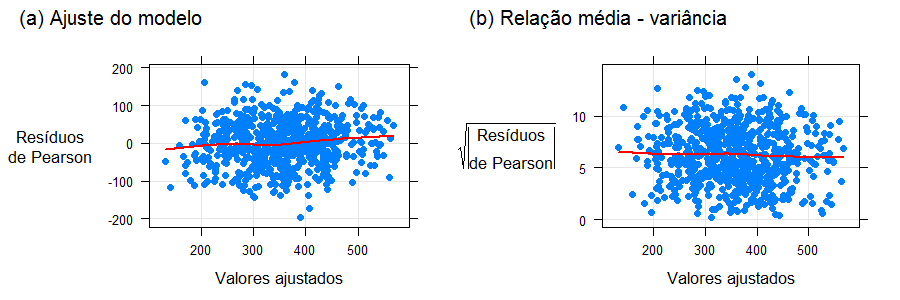

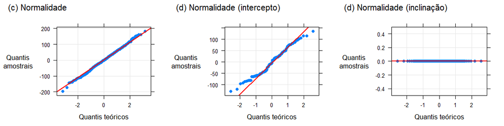

#### INFERÊNCIA

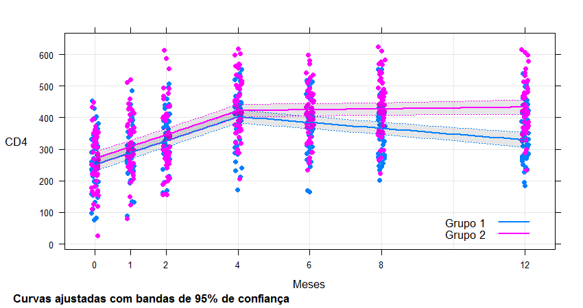

**Estimativas do modelo em células/mm$^{3}$**

Estimativa

Erro padrão

Mês 0 - `Grupo` 1

251.1166

10.6206

Mês 0 - `Grupo` 2

270.1609

10.6206

Inclinação - Mês ≤ 4

37.923

1.8412

Inclinação - `Grupo` 1

-9.1967

1.3266

Inclinação - `Grupo` 2

1.3669

1.3266

σ<sub>Id-0</sub>

63.7719

σ<sub>Id-1</sub>

0

σ

62.8239

> Os valores das estimativas são idênticas as obtidas com o modelo 1

> A única diferença é o desvio padrão da inclinação até o ponto de quebra, sua estimativa pontual é de zero

> Essa estimativa nula nos diz que a presença deste coeficiente é desnecessária, já que a princípio ele não agrega na explicação da variabilidade e que as variações na inclinação inicial dos indivíduos é sempre a mesma, 0, ou seja, para todos os indivíduos a inclinação até o ponto de quebra é a mesma, 37.92

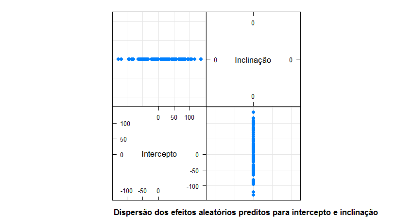

> Esse último gráfico é idêntico ao obtido com o modelo 1, que difere apenas na ausência da inclinação aleatória até o ponto de quebra

```r
anova(lm2.idm, lm.id)
```

```
Data: data
Models:
lm.id: CD4 ~ Meses + tMeses * Grupo + (1 | Id)
lm2.idm: CD4 ~ Meses + tMeses * Grupo + ((1 | Id) + (0 + Meses | Id))
        Df    AIC    BIC  logLik deviance Chisq Chi Df Pr(>Chisq)
lm.id    7 8002.5 8034.4 -3994.3   7988.5
lm2.idm  8 8004.5 8040.9 -3994.3   7988.5     0      1          1
```

> Com um teste de razão de verossimilhança comparamos o modelo 4 com o modelo 1

> Observe que ficamos com o modelo 1, i.e., sem a inclinação aleatória até o ponto de quebra

### COMPARANDO OS MODELOS 3 E 4

**Comparando as estimativas de contagens de `CD4` dos dois modelos**

Modelo 3

Modelo 4

Estimativa

Erro padrão

Estimativa

Erro padrão

Mês 0 - `Grupo` 1

250.9049

10.8059

251.1166

10.6206

Mês 0 - `Grupo` 2

270.3726

10.8059

270.1609

10.6206

Inclinação - Mês ≤ 4

37.923

1.8409

37.923

1.8412

Inclinação - `Grupo` 1

-9.1949

1.3279

-9.1967

1.3266

Inclinação - `Grupo` 2

1.3651

1.3279

1.3669

1.3266

σ<sub>Id-0</sub>

65.7636

63.7719

σ<sub>Id-1</sub>

0.4216

0

σ

62.7982

62.8239

> Nas análises gráficas de resíduos verificamos que ambos os modelos ajustaram satisfatóriamente

**Medidas de comparação dos modelos**

| Modelo 3 AIC | Modelo 3 BIC | Modelo 3 logLik | Modelo 3 REML |  | Modelo 4 AIC | Modelo 4 BIC | Modelo 4 logLik | Modelo 4 REML |
| --- | --- | --- | --- | --- | --- | --- | --- | --- |
| 7985.9721 | 8026.9318 | -3983.986 | 7967.9721 |  | 7984.3992 | 8020.8079 | -3984.1996 | 7968.3992 |

O AIC, BIC e REML são critérios do tipo menor é melhor, já a log verossimilhança é do tipo maior é melhor

> Pelo AIC e BIC ficamos com o modelo 4, pela log-verossimilhança e REML ficamos com o modelo 3. Não obstante o modelo 3 possui um parâmetro a mais, e o ganho na verossimilhança parece ser pequeno dado o acréscimo de um parâmetro

```r
anova(lm.idm, lm2.idm)
```

```
Data: data
Models:
lm2.idm: CD4 ~ Meses + tMeses * Grupo + ((1 | Id) + (0 + Meses | Id))
lm.idm: CD4 ~ Meses + tMeses * Grupo + (Meses | Id)
        Df    AIC    BIC  logLik deviance  Chisq Chi Df Pr(>Chisq)
lm2.idm  8 8004.5 8040.9 -3994.3   7988.5
lm.idm   9 8006.1 8047.1 -3994.0   7988.1 0.4289      1     0.5125
```

Fazendo um teste de razão de verossimilhança ficamos com o modelo 4

> Contudo, já vimos que o modelo 1 (sem inclinação aleatória até o ponto de quebra) se mostra mais adequado que os modelos 3 e 4

## INTERCEPTO E INCLINAÇÃO FINAL ALEATÓRIA

### MODELO 5

> $\begin{align} {\rm CD4}_{ij} & = \mu + \beta_{m} {\rm Meses}_{i} + \beta_{t} {\rm tMeses}_{i} + \beta_{g} {\rm Grupo}_{j} + \beta_{tg} {\rm tMeses}_{i} \cdot {\rm Grupo}_{j} \\ & + \gamma_{j}^{0} + \gamma_{j}^{1} {\rm tMeses}_{i} + \epsilon_{ij} \end{align}$

onde $i$ indexa o mês e $j$ indexa o indivíduo

O que diferencia esse modelo do modelo 1 é o acréscimo de mais um termo de efeito aleatório

```r
# lm.idt: modelo linear com efeito aleatório de indivíduo (intercepto aleatório)
#         e de indivíduo dentro de tmeses (inclinação aleatória depois do ponto de quebra)
lm.idt <- lmer(CD4 ~ Meses + tMeses*Grupo + (tMeses|Id), data)
```

#### E A QUALIDADE DO AJUSTE? FICOU BOM?

*Verificação dos pressupostos e ajuste do modelo*  
**O ajuste do modelo se mostra satisfatório e os pressupostos são atendidos**

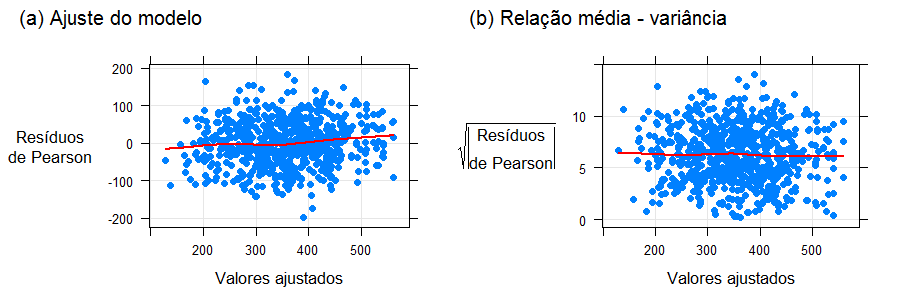

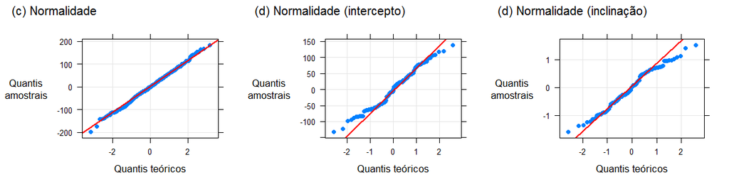

#### INFERÊNCIA

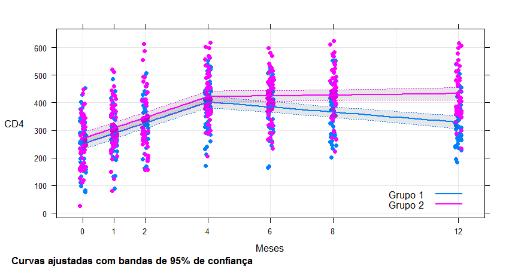

**Estimativas de efeito fixo do modelo em células/mm$^{3}$**

|  | Estimativa | Erro padrão |
| --- | --- | --- |
| Mês 0 - `Grupo` 1 | 251.1166 | 10.7994 |
| Mês 0 - `Grupo` 2 | 270.1609 | 10.7994 |
| Inclinação - Mês ≤ 4 | 37.923 | 1.84 |
| Inclinação - `Grupo` 1 | -9.1967 | 1.3299 |
| Inclinação - `Grupo` 2 | 1.3669 | 1.3299 |

> Considerar um efeito aleatório dos indivíduos e dos indivíduos dentro de `tMeses` significa inserir um diferente intercepto e inclinação depois do ponto de quebra para cada indivíduo

```r
VarCorr(lm.idt)
```

```
 Groups   Name        Std.Dev. Corr
 Id       (Intercept) 65.27149
          tMeses       0.74659 -1.000
 Residual             62.78243
```

> Atente para o valor da correlação estimada entre o intercepto e a inclinação aleatórios. A estimativa é de -1

> Isso mostra que o intercepto e a inclinação são altamente correlacionados e que essa correlação é negativa, i.e., para baixos valores de um deles temos altos valores do outro

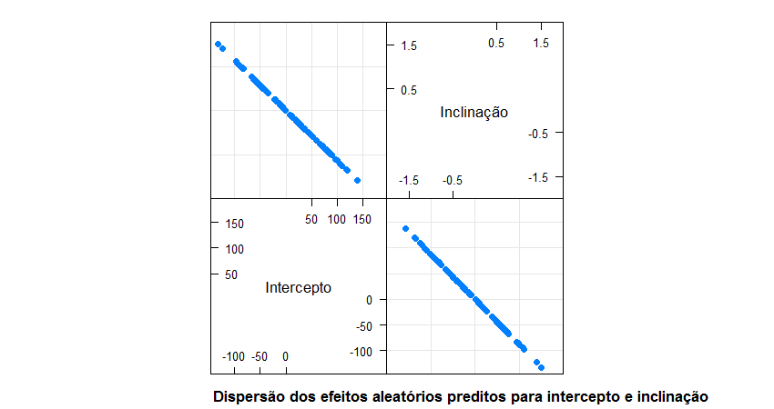

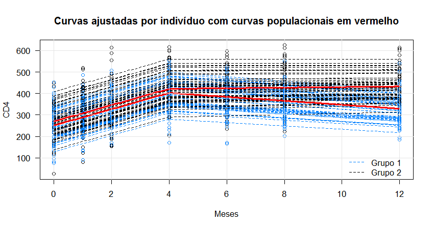

```r
anova(lm.idt, lm.id)
```

```
Data: data
Models:
lm.id: CD4 ~ Meses + tMeses * Grupo + (1 | Id)
lm.idt: CD4 ~ Meses + tMeses * Grupo + (tMeses | Id)
       Df    AIC    BIC  logLik deviance  Chisq Chi Df Pr(>Chisq)
lm.id   7 8002.5 8034.4 -3994.3   7988.5
lm.idt  9 8005.8 8046.8 -3993.9   7987.8 0.6938      2     0.7069
```

> Com um teste de razão de verossimilhança comparamos o modelo 5 com o modelo 1

> Observe que ficamos com o modelo 1, i.e., sem a inclinação aleatória depois do ponto de quebra

### MODELO 6

> Podemos escrever o modelo 5 considerando que o intercepto e a inclinação aleatórios são não correlacionados

```r
# lm2.idt: modelo linear com efeito aleatório de indivíduo (intercepto aleatório)
#          e de indivíduo dentro de meses (inclinação aleatória depois do ponto de quebra)
#          não correlacionados
lm2.idt <- lmer(CD4 ~ Meses + tMeses*Grupo + (tMeses||Id), data)
```

#### E A QUALIDADE DO AJUSTE? FICOU BOM?

*Verificação dos pressupostos e ajuste do modelo*  
**O ajuste do modelo se mostra satisfatório e os pressupostos são atendidos**

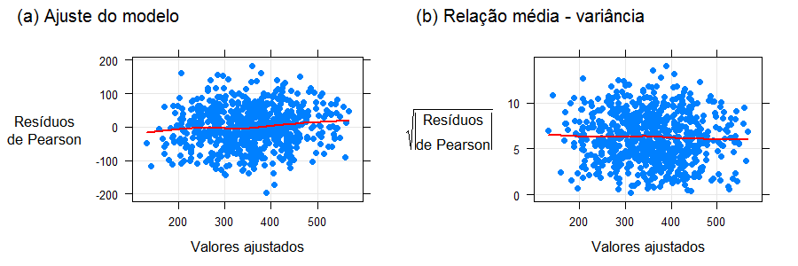

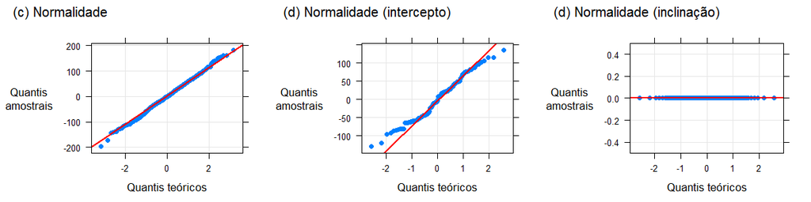

#### INFERÊNCIA

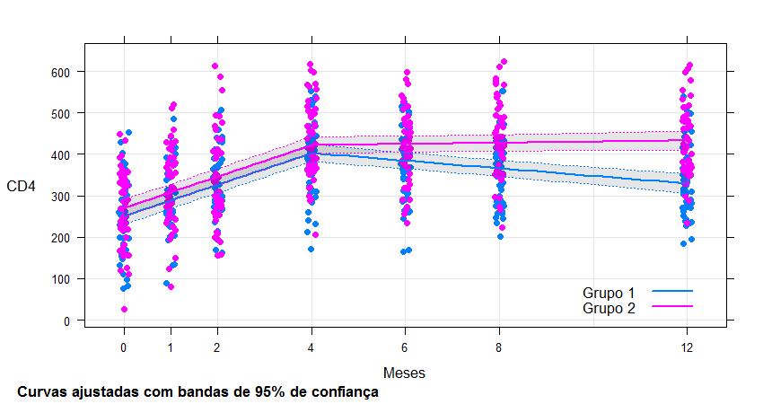

**Estimativas do modelo**

Estimativa

Erro padrão

Mês 0 - `Grupo` 1

251.1166

10.6206

Mês 0 - `Grupo` 2

270.1609

10.6206

Inclinação - Mês ≤ 4

37.923

1.8412

Inclinação - `Grupo` 1

-9.1967

1.3266

Inclinação - `Grupo` 2

1.3669

1.3266

σ<sub>Id-0</sub>

63.7719

σ<sub>Id-1</sub>

0

σ

62.8239

> Os valores das estimativas são idênticas as obtidas com o modelo 1

> A única diferença é o desvio padrão da inclinação depois do ponto de quebra, sua estimativa pontual é de zero

> Essa estimativa nula nos diz que a presença deste coeficiente é desnecessária, já que a princípio ele não agrega na explicação da variabilidade e que as variações na inclinação dos indivíduos é sempre a mesma, 0

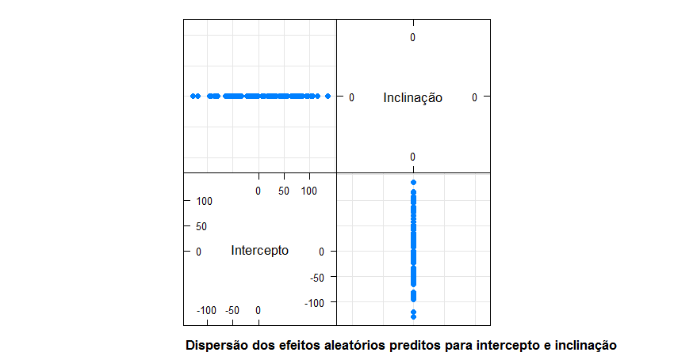

> Esse último gráfico é idêntico ao obtido com o modelo 1

```r
anova(lm2.idt, lm.id)
```

```
Data: data
Models:
lm.id: CD4 ~ Meses + tMeses * Grupo + (1 | Id)
lm2.idt: CD4 ~ Meses + tMeses * Grupo + ((1 | Id) + (0 + tMeses | Id))
        Df    AIC    BIC  logLik deviance Chisq Chi Df Pr(>Chisq)
lm.id    7 8002.5 8034.4 -3994.3   7988.5
lm2.idt  8 8004.5 8040.9 -3994.3   7988.5     0      1          1
```

> Com um teste de razão de verossimilhança comparamos o modelo 6 com o modelo 1, eles diferem pela inserção de uma inclinação aleatória depois do ponto de quebra

### COMPARANDO OS MODELOS 5 E 6

**Comparando as estimativas de contagens de `CD4` dos dois modelos**

Estimativa

Erro padrão

Estimativa

Erro padrão

Mês 0 - `Grupo` 1

251.1166

10.7994

251.1166

10.6206

Mês 0 - `Grupo` 2

270.1609

10.7994

270.1609

10.6206

Inclinação - Mês ≤ 4

37.923

1.84

37.923

1.8412

Inclinação - `Grupo` 1

-9.1967

1.3299

-9.1967

1.3266

Inclinação - `Grupo` 2

1.3669

1.3299

1.3669

1.3266

σ<sub>Id-0</sub>

65.2715

63.7719

σ<sub>Id-1</sub>

0.7466

0

σ

62.7824

62.8239

> Nas análises gráficas de resíduos verificamos que ambos os modelos ajustaram satisfatóriamente

**Medidas de comparação dos modelos**

| Modelo 5 AIC | Modelo 5 BIC | Modelo 5 logLik | Modelo 5 REML |  | Modelo 6 AIC | Modelo 6 BIC | Modelo 6 logLik | Modelo 6 REML |
| --- | --- | --- | --- | --- | --- | --- | --- | --- |
| 7985.7075 | 8026.6672 | -3983.8537 | 7967.7075 |  | 7984.3992 | 8020.8079 | -3984.1996 | 7968.3992 |

O AIC, BIC e REML são critérios do tipo menor é melhor, já a log verossimilhança é do tipo maior é melhor

> Pelo AIC e BIC ficamos com o modelo 6, pela log-verossimilhança e REML ficamos com o modelo 5. Não obstante o modelo 5 possui um parâmetro a mais, e o ganho na verossimilhança parece ser pequeno dado o acréscimo de um parâmetro

```r
anova(lm.idt, lm2.idt)
```

```
Data: data
Models:
lm2.idt: CD4 ~ Meses + tMeses * Grupo + ((1 | Id) + (0 + tMeses | Id))
lm.idt: CD4 ~ Meses + tMeses * Grupo + (tMeses | Id)
        Df    AIC    BIC  logLik deviance  Chisq Chi Df Pr(>Chisq)
lm2.idt  8 8004.5 8040.9 -3994.3   7988.5
lm.idt   9 8005.8 8046.8 -3993.9   7987.8 0.6938      1     0.4049
```

> Contudo, já vimos que o modelo 1 (sem inclinação aleatória depois do ponto de quebra) se mostra mais adequado que os modelos 5 e 6

## INTERCEPTO ALEATÓRIO E FUNÇÃO QUADRÁTICA ATÉ O PONTO DE QUEBRA

### MODELO 7

Por enquanto ficamos com o modelo 1, i.e., ficamos com o modelo apenas com o intercepto aleatório

Até agora estamos ajustando retas, mas podemos pensar numa curva quadrática até o ponto de quebra

> $\begin{align} {\rm CD4}_{ij} & = \mu + \beta_{m} {\rm Meses}_{i} + \beta_{t2} {\rm Meses}_{i}^{2} + \beta_{t} {\rm tMeses}_{i} + \beta_{g} {\rm Grupo}_{j} + \beta_{tg} {\rm tMeses}_{i} \cdot {\rm Grupo}_{j} \\ & + \gamma_{j}^{0} + \epsilon_{ij} \end{align}$

onde $i$ indexa o mês e $j$ indexa o indivíduo

```r
# lm.id2: modelo linear com efeito aleatório de indivíduo (intercepto aleatório)
#         e termo quadrático até o ponto de quebra
lm.id2 <- lmer(CD4 ~ Meses + I(Meses**2) + tMeses*Grupo + (1|Id), data)
```

#### E A QUALIDADE DO AJUSTE? FICOU BOM?

*Verificação dos pressupostos e ajuste do modelo*  
**O ajuste do modelo se mostra satisfatório e os pressupostos são atendidos**

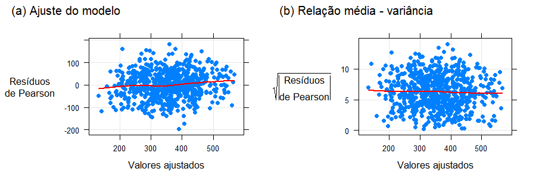

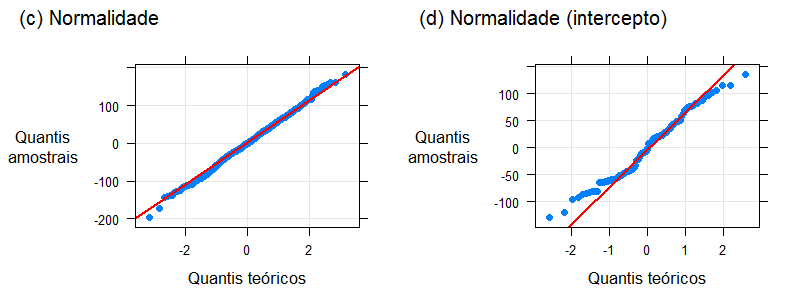

#### INFERÊNCIA

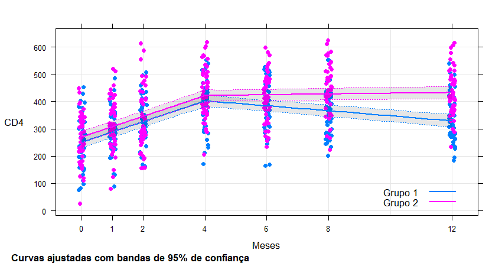

> Observamos o mesmo comportamento dos demais gráficos, isso nos diz que o termo quadrático não é significativo

**Estimativas do modelo em células/mm$^{3}$**

Estimativa

Erro padrão

Mês 0 - `Grupo` 1

251.1042

10.6237

Mês 0 - `Grupo` 2

270.1485

10.6237

Inclinação (x) - Mês ≤ 4

37.9872

2.0622

Inclinação (x²) - Mês ≤ 4

-0.0307

0.4426

Inclinação - `Grupo` 1

-8.7274

6.8969

Inclinação - `Grupo` 2

1.8362

6.8969

σ<sub>Id</sub>

63.7645

σ

62.8763

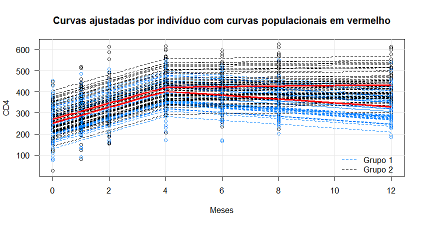

```r
anova(lm.id2, lm.id)
```

```
Data: data
Models:
lm.id: CD4 ~ Meses + tMeses * Grupo + (1 | Id)
lm.id2: CD4 ~ Meses + I(Meses^2) + tMeses * Grupo + (1 | Id)
       Df    AIC    BIC  logLik deviance  Chisq Chi Df Pr(>Chisq)
lm.id   7 8002.5 8034.4 -3994.3   7988.5
lm.id2  8 8004.5 8040.9 -3994.3   7988.5 0.0048      1     0.9445
```

Com o teste de razão de verossimilhança temos a confirmação de que a inserção do termo quadrático não é estatísticamente significativa, i.e., os dados são melhores descritos pela reta até o ponto de quebra